# Assignment 4

Tejas Athni

11/7/2020

BACKGROUND: In 2013 and 2014, a surging tech-sector economy made these years some of the best for overall Bay Area commercial real estate prices. According to a Mercury News article published in November 2013, new construction and renovation of real estate within the Bay Area (e.g., hotel, industrial, office, and retail properties) exceeded $6 billion across the Bay Area, based on data from the reputable development company McGraw Hill Construction. Further, an article by Guerra et al., 2018 suggests that home sales and real estate/property prices are directly tied to economic activity and mirrors its trends in rise and fall. A specific event of interest is the construction of the San Francisco 49ers Levi’s Stadium in Santa Clara County, which started in 2013 and opened in 2014. This sports-venue opening could have potentially caused an additional surge in economic activity and property value on top of the 2013 tech boom – a finding which would advance the idea of multi-sector booms synthesizing to yield economic success.

INTRODUCTION: In this analysis, I hypothesize that in addition to the trend of increased economic activity causing real estate prices to go upwards, we should be able to witness further regional effects of additionally-increased property values in the Santa Clara County PUMA containing the new San Francisco 49ers’ stadium. To operationalize this, I assess the extent to which the number of households that have a property value (VALP variable in PUMS) higher than the average California property value (~$580,000) have changed from pre-2014 to post-2014 in the Santa Clara PUMA which contains Levi’s Stadium. I use a difference-in-difference design, setting my counterfactual to be a matched, Bay Area county PUMA that can serve as a control for this quasi-experiment.

My null hypothesis is that there is no difference between pre-2014 and post-2014 number of households above the average California property value in the PUMA containing Levi’s Stadium (which would hint at no additional real estate increase with the opening of the football venue), as compared to the mean number of households above CA-standard property value averaged across 5 matched PUMAs. Matched PUMAs are defined as those that experience similar property value trends to the Levi’s Stadium-containing PUMA in the two years prior to 2014.

SETUP: In this first chunk of code, I load the relevant libraries of interest and set the census key.

```r
library(tidyverse)
library(plotly)
library(sf)
library(tigris)
library(leaflet)
library(censusapi)
library(tidycensus)
library(corrplot)
library(dplyr)
library(StatMatch)
Sys.setenv(CENSUS_KEY="0b20d8e27e52741cf293056779d3caf7e3793f0a")
setwd("E:/SynologyDrive/Tejas_Server/! Stanford University/! Year 3 - Quarter 1/PoliSci 218X/Assignment 4")
```

LOCATE: I will first pinpoint the geolocation of the Levi’s Stadium on the map and will select the specific PUMA in Santa Clara county containing the stadium.

```r
ca_pumas <- pumas("CA", cb = T, progress_bar = F)
ca_counties <- counties("CA", cb = T, progress_bar = F)
bay_county_names <- c("Alameda",
                      "Contra Costa",
                      "Marin",
                      "Napa",
                      "San Francisco",
                      "San Mateo",
                      "Santa Clara",
                      "Solano",
                      "Sonoma")
bay_counties <- ca_counties %>% filter(NAME %in% bay_county_names)
santa_clara <- ca_counties %>% filter(NAME == "Santa Clara")

bay_pumas <-
  ca_pumas %>%
  st_centroid() %>%
  .[bay_counties, ] %>%
  st_set_geometry(NULL) %>%
  left_join(ca_pumas %>% select(GEOID10)) %>%
  st_as_sf()

santa_clara_pumas <-
  ca_pumas %>%
  st_centroid() %>%
  .[santa_clara, ] %>%
  st_set_geometry(NULL) %>%
  left_join(ca_pumas %>% select(GEOID10)) %>%
  st_as_sf()


leaflet() %>%
  addProviderTiles(providers$CartoDB.Positron) %>%
  addPolygons(
    data = bay_pumas,
    weight = 1,
    color = "gray"
  ) %>%
  addMarkers(
    lng = -121.96968170505542,
    lat = 37.40303995
  ) %>%
  addPolygons(
    data = bay_pumas %>%
      filter(PUMACE10 == "08503")
  )
```

[interactive chart not shown]

MATCHING: Before I perform the difference-in-difference analysis, I will match the Santa Clara PUMA housing Levi’s Stadium with 5 control PUMAs.

```r
pums_property_value <-
  2012:2014 %>%
  map_dfr(function(year){
    get_pums(
      variables = c(
        "PUMA",
        "VALP"
      ),
      state = "CA",
      year = year,
      survey = "acs1",
      recode = F
    ) %>%
      filter(SPORDER == 1) %>%
      mutate(
        num_above_CA_avg = ifelse(
          VALP >= 580000,
          WGTP,
          0
        ),
        PUMA = PUMA %>% str_pad(5,"left","0")
      ) %>%
      group_by(PUMA) %>%
      summarize(
        households = sum(WGTP),
        sum_above_CA_avg = sum(num_above_CA_avg),
        year = year
      )
  })
```

```r
pums_pal <- colorNumeric(
  palette = "YlOrRd",
  domain = pums_property_value$households
)

leaflet() %>%
  addProviderTiles(providers$CartoDB.Positron) %>%
  addPolygons(
    data = pums_property_value %>%
      right_join(bay_pumas %>% select(PUMA = PUMACE10)) %>%
      st_as_sf(),
    fillColor = ~pums_pal(households),
    color = "white",
    weight = 1,
    label = ~paste0(PUMA,": Households ", households)
  )
```

[interactive chart not shown]

```r
pums_pal <- colorNumeric(
  palette = "GnBu",
  domain = pums_property_value$sum_above_CA_avg
)

leaflet() %>%
  addProviderTiles(providers$CartoDB.Positron) %>%
  addPolygons(
    data = pums_property_value %>%
      right_join(bay_pumas %>% select(PUMA = PUMACE10)) %>%
      st_as_sf(),
    fillColor = ~pums_pal(sum_above_CA_avg),
    color = "white",
    weight = 1,
    label = ~paste0(PUMA,": ", sum_above_CA_avg, " Households Above the Average California Property Value")
  )
```

[interactive chart not shown]

```r
pums_property_value_clean <-
  pums_property_value %>%
  select(-households) %>%
  pivot_wider(
    names_from = year,
    values_from = sum_above_CA_avg
  ) %>%
  filter(PUMA %in% bay_pumas$PUMACE10)



obs_matrix <-
  pums_property_value_clean %>%
  select(`2012`,`2013`) %>%
  as.matrix()

dist_matrix <- mahalanobis.dist(obs_matrix)

rownames(dist_matrix) <- pums_property_value_clean$PUMA
colnames(dist_matrix) <- pums_property_value_clean$PUMA

match <- dist_matrix["08503",] %>%
  as.data.frame() %>%
  rownames_to_column() %>%
  rename(
    PUMA = rowname,
    match = "."
  ) %>%
  right_join(
    pums_property_value_clean
  ) %>%
  arrange(match) %>%
  .[1:6, ] %>%
  left_join(bay_pumas %>% select(PUMA = PUMACE10)) %>%
  st_as_sf()

leaflet() %>%
  addTiles() %>%
  addProviderTiles(providers$CartoDB.Positron) %>%
  addPolygons(
    data = match[1, ],
    color = "red",
    label = ~PUMA
  ) %>%
  addPolygons(
    data = match[-1, ],
    label = ~PUMA
  )
```

[interactive chart not shown]

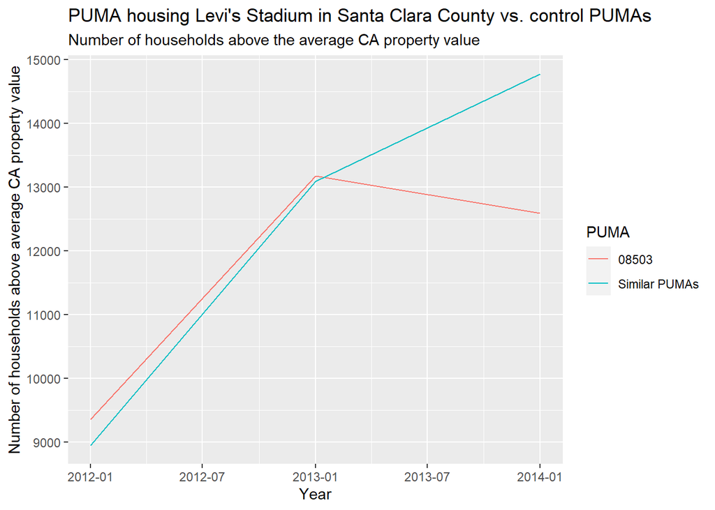

```r
match_pumas <-
  match[-1,] %>%
  st_set_geometry(NULL) %>%
  select(-match) %>%
  pivot_longer(
    -PUMA,
    names_to = "year",
    values_to = "sum_above_CA_avg"
  ) %>%
  group_by(
    year
  ) %>%
  summarize(
    sum_above_CA_avg = mean(sum_above_CA_avg),
    PUMA = "Similar PUMAs"
  )

treatment_puma <-
  match[1,] %>%
  select(-match) %>%
  st_set_geometry(NULL) %>%
  pivot_longer(
    -PUMA,
    names_to = "year",
    values_to = "sum_above_CA_avg"
  )

rbind(
  treatment_puma,
  match_pumas
) %>%
  mutate(
    year = year %>% paste0(.,"-01-01") %>%  as.Date()
  ) %>%
  ggplot(
    aes(
      x = year,
      y = sum_above_CA_avg,
      color = PUMA
    )
  ) +
  geom_line() +
  geom_vline(xintercept = 2014, linetype = "dashed") +
  labs(
    title = "PUMA housing Levi's Stadium in Santa Clara County vs. control PUMAs",
    subtitle = "Number of households above the average CA property value",
    x = "Year",
    y = "Number of households above average CA property value"
  )
```

DIFFERENCE-IN-DIFFERENCE ANALYSIS:

```r
propvalue_did <-
  match %>%
  st_set_geometry(NULL) %>%
  select(-match) %>%
  pivot_longer(
    -PUMA,
    names_to = "year",
    values_to = "sum_above_CA_avg"
  ) %>%
  mutate(
    year = year %>% as.numeric(),
    time = ifelse(year == 2014, 1, 0),
    treated = ifelse(PUMA == "08503", 1, 0)
  )

did_reg <- lm(sum_above_CA_avg ~ treated*time, data = propvalue_did)

summary(did_reg)
```

```
##
## Call:
## lm(formula = sum_above_CA_avg ~ treated * time, data = propvalue_did)
##
## Residuals:
##     Min      1Q  Median      3Q     Max
## -4283.4 -1289.2  -254.9  1738.3  3847.6
##
## Coefficients:
##              Estimate Std. Error t value Pr(>|t|)
## (Intercept)   11019.4      752.1  14.651 6.95e-10 ***
## treated         245.1     1842.3   0.133   0.8961
## time           3750.6     1302.7   2.879   0.0121 *
## treated:time  -2421.1     3191.0  -0.759   0.4606
## ---
## Signif. codes:  0 '***' 0.001 '**' 0.01 '*' 0.05 '.' 0.1 ' ' 1
##
## Residual standard error: 2378 on 14 degrees of freedom
## Multiple R-squared:  0.3815, Adjusted R-squared:  0.249
## F-statistic: 2.879 on 3 and 14 DF,  p-value: 0.07347
```

RESULTS: Analyzing the beta coefficient for the treated:time, which is the difference-in-differences result of interest, we see that the Levi’s Stadium construction in 2013 and opening in 2014 had an estimated impact of roughly 2,400 fewer households that have property values above the CA-state property average value. This result is opposite of what I had expected from the outset, with my hypothesis being that the Levi’s Stadium construction should boost economic activity and thus property value in its vicinity. It seems that the construction of the Levi’s Stadium actually devaluated the property value of the households nearby the stadium, perhaps due to worse-maintained infrastructure or environmental waste that is produced by the stadium operations itself or auxiliary operations. However, we must keep in mind that the p-value of 0.46 for the interaction term coefficient is NOT statistically significant with a 5% significance threshold, and thus the null hypothesis CANNOT be rejected and any firm conclusions are not valid.

There are many assumptions that went into this analysis. For example, I am assuming that the outcome PUMS variable VALP (property value) is accurate, and that homeowners do not skew their own metric and overestimate their property value, as would be expected by human psychological bias. Property value can also be misinterpreted by the survey respondents, with some choosing to report house + land value, while others may only choose to report their house value. This inherent discrepancy may be confounding the true results. Additionally, I chose to look at only the 2 years prior to the 2014 date of stadium opening, which might have been too short of a study window. Future directions might include a longer period of study for the diff-in-diff analysis, leading to better matching and also better evaluation of the impact of the stadium construction.

Furthermore, I could have chosen to use a higher number of matching PUMAs via Mahalanobis distance, instead of the 5 matches that I used in this current analysis. I also did not control for other pertinent variables, such as race, gender, income, and employment status, as would have been done in a multiple regression analysis.